# Paper Metrics Across Three Run Options (Facet Rows)

## 1) Packages

```r
required_pkgs <- c("jsonlite", "dplyr", "tidyr", "purrr", "ggplot2", "readr", "stringr")
missing_pkgs <- required_pkgs[!vapply(required_pkgs, requireNamespace, logical(1), quietly = TRUE)]
if (length(missing_pkgs) > 0) {
  stop("Missing R packages: ", paste(missing_pkgs, collapse = ", "))
}

library(jsonlite)
library(dplyr)
library(tidyr)
library(purrr)
library(ggplot2)
library(readr)
library(stringr)
```

## 2) Inputs

```r
n_runs <- 10L
seed_start <- 2026L

# Update these roots if your downloaded/server folders differ.
run_sources <- tibble::tribble(
  ~run_option, ~alg_dir, ~json_name, ~roots,
  "Server_SnapATAC", "snapatac", "snapatac.json", list(c("D:/Codex/Test/downloaded_results/server_json_runs")),
  "Server_InnerProduct", "innerproduct", "innerproduct.json", list(c("D:/Codex/Test/downloaded_results/server_json_runs")),
  "Local_InnerProduct", "innerproduct", "innerproduct.json", list(c("D:/Codex/Test/results"))
)
```

## 3) Resolve JSON Paths

```r
resolve_json_path <- function(roots, method_name, run_idx, alg_dir, json_name) {
  dset <- sprintf("oocyte_zygote_%s_pairs_r%02d", method_name, run_idx)
  # Layout A: <root>/<dset>/1M/<alg>/<json>
  candidates_a <- file.path(roots, dset, "1M", alg_dir, json_name)
  # Layout B: <root>/<alg>/<method>/<dset>_1M_<alg>.json (optional custom naming)
  candidates_b <- file.path(roots, alg_dir, method_name, sprintf("%s_1M_%s", dset, json_name))
  # Layout C: <root>/<alg>/<method>/<json> (single-run copy; not ideal but supported)
  candidates_c <- file.path(roots, alg_dir, method_name, json_name)
  candidates <- c(candidates_a, candidates_b, candidates_c)
  hit <- candidates[file.exists(candidates)]
  if (length(hit) > 0) return(hit[[1]])
  NA_character_
}

path_tbl <- tidyr::expand_grid(
  run_option = run_sources$run_option,
  method = c("raw", "bhzip"),
  run = seq_len(n_runs)
) %>%
  left_join(run_sources, by = "run_option") %>%
  mutate(
    seed = seed_start + run - 1L,
    json_path = purrr::pmap_chr(
      list(roots, method, run, alg_dir, json_name),
      resolve_json_path
    ),
    exists = !is.na(json_path)
  )

missing_tbl <- path_tbl %>% filter(!exists)
if (nrow(missing_tbl) > 0) {
  warning("Missing JSON files for some runs. They will be skipped.")
  print(missing_tbl %>% select(run_option, method, run, seed, alg_dir))
}

coverage_tbl <- path_tbl %>%
  group_by(run_option) %>%
  summarise(found = sum(exists), total = n(), .groups = "drop") %>%
  mutate(pct = sprintf("%.1f%%", 100 * found / total))
print(coverage_tbl)
```

```
## # A tibble: 3 × 4
##   run_option          found total pct
##   <chr>               <int> <int> <chr>
## 1 Local_InnerProduct     20    20 100.0%
## 2 Server_InnerProduct    20    20 100.0%
## 3 Server_SnapATAC        20    20 100.0%
```

## 4) Extract ARI/NMI/Silhouette Families + AvgBIO from JSON

```r
first_numeric <- function(x) {
  if (is.null(x)) return(NA_real_)
  if (is.list(x)) x <- unlist(x, recursive = TRUE, use.names = FALSE)
  vals <- suppressWarnings(as.numeric(x))
  if (length(vals) == 0 || all(is.na(vals))) return(NA_real_)
  vals[which(!is.na(vals))[1]]
}

extract_relevant_metrics <- function(path) {
  if (is.na(path) || !file.exists(path)) {
    return(tibble(metric = character(), value = numeric(), avgBio = numeric()))
  }

  j <- jsonlite::fromJSON(path, simplifyVector = FALSE)
  keys <- names(j)
  if (is.null(keys) || length(keys) == 0) {
    return(tibble(metric = character(), value = numeric(), avgBio = numeric()))
  }

  vals <- purrr::map_dbl(keys, ~ first_numeric(j[[.x]]))
  base_df <- tibble(metric = keys, value = vals) %>%
    filter(!is.na(value)) %>%
    filter(grepl("(ari|nmi|silhouette)", metric, ignore.case = TRUE)) %>%
    filter(!grepl("silhouette-gt", metric, ignore.case = TRUE))

  best_ari <- first_numeric(j[["best_ari"]])
  best_nmi <- first_numeric(j[["best_nmi"]])
  best_asw <- first_numeric(j[["best_silhouette"]])
  avgBio <- mean(c(best_ari, best_nmi, best_asw), na.rm = TRUE)
  if (all(is.na(c(best_ari, best_nmi, best_asw)))) avgBio <- NA_real_

  bind_rows(
    base_df,
    tibble(metric = "avgBio", value = avgBio)
  )
}

metric_order <- c(
  "ari_agglomerative", "ari_gmm", "ari_k-means", "ari_leiden", "ari_louvain", "best_ari",
  "nmi_agglomerative", "nmi_gmm", "nmi_k-means", "nmi_leiden", "nmi_louvain", "best_nmi",
  "silhouette_agglomerative", "silhouette_gmm", "silhouette_k-means",
  "silhouette_leiden", "silhouette_louvain", "best_silhouette",
  "avgBio"
)

plot_df <- path_tbl %>%
  filter(exists) %>%
  mutate(metrics = purrr::map(json_path, extract_relevant_metrics)) %>%
  tidyr::unnest(metrics) %>%
  filter(metric %in% metric_order) %>%
  mutate(
    metric = factor(metric, levels = metric_order),
    method = factor(method, levels = c("raw", "bhzip")),
    run_option = factor(run_option, levels = c("Server_SnapATAC", "Server_InnerProduct", "Local_InnerProduct"))
  ) %>%
  arrange(run_option, method, run, metric)
```

## 5) Summary

```r
summary_df <- plot_df %>%
  group_by(run_option, method, metric) %>%
  summarise(
    mean = mean(value, na.rm = TRUE),
    sd = sd(value, na.rm = TRUE),
    n = sum(!is.na(value)),
    .groups = "drop"
  ) %>%
  arrange(run_option, metric, method)

summary_fmt <- summary_df %>%
  mutate(mean_sd = sprintf("%.3f (%.3f)", mean, sd)) %>%
  select(run_option, method, metric, mean_sd, n)

print(summary_fmt, n = 100)
```

```
## # A tibble: 114 × 5
##     run_option          method metric                   mean_sd            n
##     <fct>               <fct>  <fct>                    <chr>          <int>
##   1 Server_SnapATAC     raw    ari_agglomerative        0.382 (0.000)     10
##   2 Server_SnapATAC     bhzip  ari_agglomerative        0.244 (0.000)     10
##   3 Server_SnapATAC     raw    ari_gmm                  0.254 (0.000)     10
##   4 Server_SnapATAC     bhzip  ari_gmm                  0.271 (0.000)     10
##   5 Server_SnapATAC     raw    ari_k-means              0.390 (0.000)     10
##   6 Server_SnapATAC     bhzip  ari_k-means              0.242 (0.000)     10
##   7 Server_SnapATAC     raw    ari_leiden               0.489 (0.000)     10
##   8 Server_SnapATAC     bhzip  ari_leiden               0.000 (0.000)     10
##   9 Server_SnapATAC     raw    ari_louvain              0.266 (0.000)     10
##  10 Server_SnapATAC     bhzip  ari_louvain              0.213 (0.000)     10
##  11 Server_SnapATAC     raw    best_ari                 0.489 (0.000)     10
##  12 Server_SnapATAC     bhzip  best_ari                 0.271 (0.000)     10
```

[output cut: 89 more lines]

## 6) Plot (3 Facet Rows by Run Option)

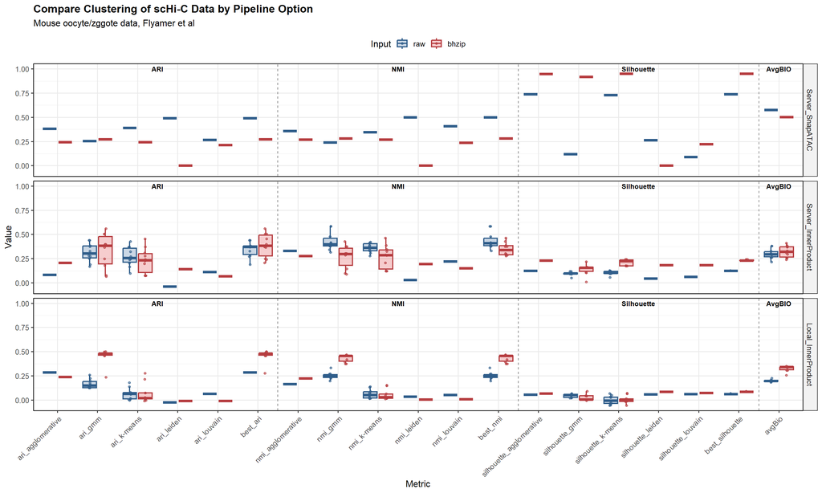

```r
# group separators and labels (same grouping idea as one-panel plot)
group_boundaries <- tibble::tibble(
  metric = levels(plot_df$metric),
  idx = seq_along(levels(plot_df$metric)),
  metric_group = case_when(
    grepl("^ari|best_ari$", metric, ignore.case = TRUE) ~ "ARI",
    grepl("^nmi|best_nmi$", metric, ignore.case = TRUE) ~ "NMI",
    grepl("silhouette", metric, ignore.case = TRUE) ~ "Silhouette",
    metric == "avgBio" ~ "AvgBIO",
    TRUE ~ "Other"
  )
)

separator_x <- group_boundaries %>%
  group_by(metric_group) %>%
  summarise(last_idx = max(idx), .groups = "drop") %>%
  arrange(last_idx)

if (nrow(separator_x) > 1) {
  separator_x <- separator_x$last_idx[seq_len(nrow(separator_x) - 1)] + 0.5
} else {
  separator_x <- numeric(0)
}

label_x <- group_boundaries %>%
  group_by(metric_group) %>%
  summarise(x = mean(idx), .groups = "drop")

facet_y <- plot_df %>%
  group_by(run_option) %>%
  summarise(y_group_label = 1, .groups = "drop")

label_df <- tidyr::crossing(facet_y, label_x)

p_rows <- ggplot(plot_df, aes(x = metric, y = value, fill = method, color = method)) +
  geom_boxplot(
    width = 0.68,
    alpha = 0.30,
    linewidth = 0.8,
    outlier.shape = NA,
    position = position_dodge(width = 0.78)
  ) +
  geom_point(
    alpha = 0.60,
    size = 1.2,
    position = position_jitterdodge(dodge.width = 0.78, jitter.width = 0.10)
  ) +
  geom_vline(
    xintercept = separator_x,
    linetype = "dashed",
    color = "grey45",
    linewidth = 0.5
  ) +
  geom_text(
    data = label_df,
    aes(x = x, y = y_group_label, label = metric_group),
    inherit.aes = FALSE,
    fontface = "bold",
    size = 3.2
  ) +
  facet_grid(run_option ~ ., scales = "fixed") +
  scale_fill_manual(values = c(raw = "#4E79A7", bhzip = "#E15759")) +
  scale_color_manual(values = c(raw = "#2F5D8A", bhzip = "#B63D40")) +
  coord_cartesian(clip = "off") +
  labs(
    title = "Compare Clustering of scHi-C Data by Pipeline Option",
    subtitle = "Mouse oocyte/zggote data, Flyamer et al",
    x = "Metric",
    y = "Value",
    fill = "Input",
    color = "Input"
  ) +
  theme_bw(base_size = 12) +
  theme(
    plot.title = element_text(face = "bold"),
    strip.background = element_rect(fill = "grey95"),
    axis.text.x = element_text(angle = 45, hjust = 1, vjust = 1),
    legend.position = "top",
    # plot.margin = margin(10, 20, 35, 10)
  )

print(p_rows)
```

ARI (Adjusted Rand Index): how well predicted clusters match known labels, corrected for chance.

NMI (Normalized Mutual Information): how much information predicted clusters share with known labels.

Silhouette (ASW): how well-separated and compact clusters are in embedding space.

Avg BIO: average of ARI, NMI, and ASW

## 7) Save Outputs

```r
out_dir <- "D:/Codex/Test/downloaded_results/paper_metrics_three_runs"
dir.create(out_dir, recursive = TRUE, showWarnings = FALSE)

readr::write_csv(path_tbl, file.path(out_dir, "json_path_resolution_table.csv"))
readr::write_csv(coverage_tbl, file.path(out_dir, "json_path_coverage_by_run_option.csv"))
readr::write_csv(plot_df, file.path(out_dir, "relevant_metrics_plus_avgbio_per_run.csv"))
readr::write_csv(summary_df, file.path(out_dir, "paper_metrics_summary_mean_sd.csv"))

ggsave(
  filename = file.path(out_dir, "paper_metrics_three_rows_facet.png"),
  plot = p_rows,
  width = 12,
  height = 11,
  dpi = 220
)

cat("Saved outputs to:", out_dir, "\n")
```

```
## Saved outputs to: D:/Codex/Test/downloaded_results/paper_metrics_three_runs
```

## 8) Run 1 Celltype Embedding Plots (3 Run Options x 2 Methods)

```r
resolve_embedding_png <- function(roots, method_name, run_idx, alg_dir) {
  dset <- sprintf("oocyte_zygote_%s_pairs_r%02d", method_name, run_idx)
  candidates <- file.path(roots, dset, "1M", alg_dir, "celltype_plots", "embedding.png")
  hit <- candidates[file.exists(candidates)]
  if (length(hit) > 0) return(hit[[1]])
  NA_character_
}

embed_tbl <- tidyr::expand_grid(
  run_option = run_sources$run_option,
  method = c("raw", "bhzip")
) %>%
  left_join(run_sources, by = "run_option") %>%
  mutate(
    run = 1L,
    seed = seed_start,
    embedding_png = purrr::pmap_chr(
      list(roots, method, run, alg_dir),
      resolve_embedding_png
    ),
    exists = !is.na(embedding_png)
  ) %>%
  select(run_option, method, run, seed, embedding_png, exists)

# print(embed_tbl)

if (all(embed_tbl$exists)) {
  show_tbl <- embed_tbl %>%
    arrange(run_option, method)

  for (i in seq_len(nrow(show_tbl))) {
    row <- show_tbl[i, ]
    cat(
      sprintf(
        "### %s | %s | run %d | seed %d\n\n",
        row$run_option, row$method, row$run, row$seed
      )
    )
    print(knitr::include_graphics(row$embedding_png))
    cat("\n\n")
  }
} else {
  cat("Some celltype embedding.png files are missing for run 1:\n")
  print(embed_tbl %>% filter(!exists))
}
```

[output not shown]